# Loan Prediction - R Notebook

```r
VI_cart=data.frame(prunedTree$variable.importance)
VI_cart
```

|  | prunedTree.variable.importance |
| --- | --- |
| Education | 237.139737 |
| Income_(in_K/month) | 166.956935 |
| Family_members | 160.140394 |
| CCAvg | 81.631983 |
| CD_Account | 57.959573 |
| Mortgage | 20.506291 |
| Age_(in_years) | 9.209210 |
| Experience_(in_years) | 8.175319 |
| Online | 2.759612 |

#Prediction using CART for train Data #Creating Confusion Matrix

```r
set.seed(127)
trData$predict.class<-predict(prunedTree,data=trData,type="class")
trData$predict.score<-predict(prunedTree,data=trData)


cfMatrix<-table(trData$Personal_Loan,trData$predict.class)
trueNegative<-cfMatrix[1,1]
falsePositive<-cfMatrix[1,2]
falseNegative<-cfMatrix[2,1]
truePositive<-cfMatrix[2,2]

cfMatrix
```

```
##
##        0    1
##   0 3156    8
##   1   35  301
```

#Performance Measures for train Data

```r
sensetivity=truePositive/(truePositive+falseNegative)
sprintf("Senstivity: %s", sensetivity)
```

```
## [1] "Senstivity: 0.895833333333333"
```

```r
specificity=trueNegative/(trueNegative+falsePositive)
sprintf("Specificity: %s", specificity)
```

```
## [1] "Specificity: 0.997471554993679"
```

```r
accuracy=(truePositive+trueNegative)/(truePositive+trueNegative+falsePositive+falseNegative)
sprintf("Accuracy: %s", accuracy)
```

```
## [1] "Accuracy: 0.987714285714286"
```

#Prediction for test Data

```r
tstData$predict.class=predict(prunedTree, tstData, type = "class")
tstData$predict.score=predict(prunedTree,tstData)

cfMatrix_test<-table(tstData$Personal_Loan,tstData$predict.class)
trueNegative_test<-cfMatrix_test[1,1]
falsePositive_test<-cfMatrix_test[1,2]
falseNegative_test<-cfMatrix_test[2,1]
truePositive_test<-cfMatrix_test[2,2]
cfMatrix_test
```

```
##
##        0    1
##   0 1351    5
##   1   16  128
```

#Performance Measure for test Data

```r
sensetivity_test=truePositive_test/(truePositive_test+falseNegative_test)
sprintf("Senstivity: %s", sensetivity_test)
```

```
## [1] "Senstivity: 0.888888888888889"
```

```r
specificity_test=trueNegative_test/(trueNegative_test+falsePositive_test)
sprintf("Specificity: %s", specificity_test)
```

```
## [1] "Specificity: 0.996312684365782"
```

```r
accuracy_test=(truePositive_test+trueNegative_test)/(truePositive_test+trueNegative_test+falsePositive_test+falseNegative_test)
sprintf("Accuracy: %s", accuracy_test)
```

```
## [1] "Accuracy: 0.986"
```

#Combining Model Performance of test and train

```r
df_results_train = data.frame(accuracy, sensetivity, specificity)
names(df_results_train) = c("ACC", "SENS", "SPEC")
df_results_test = data.frame(accuracy_test, sensetivity_test, specificity_test)
names(df_results_test) = c("ACC", "SENS", "SPEC")

?rbind
```

```
## starting httpd help server ... done
```

```r
df_fin =rbind(df_results_train, df_results_test)
row.names(df_fin) = c('tree_full_train', 'tree_full_test')
df_fin
```

|  | ACC | SENS | SPEC |
| --- | --- | --- | --- |
| tree_full_train | 0.9877143 | 0.8958333 | 0.9974716 |
| tree_full_test | 0.9860000 | 0.8888889 | 0.9963127 |

##Calculating AUC with best model

```r
## Predict using the CART model
trData$predict.class=predict(prunedTree,trData,type="class")
trData$predict.score=predict(prunedTree,trData)
tstData$predict.score=predict(prunedTree,tstData)
```

```r
library(pROC)
roc_obj = roc(trData$Personal_Loan, trData$predict.score[,2])
```

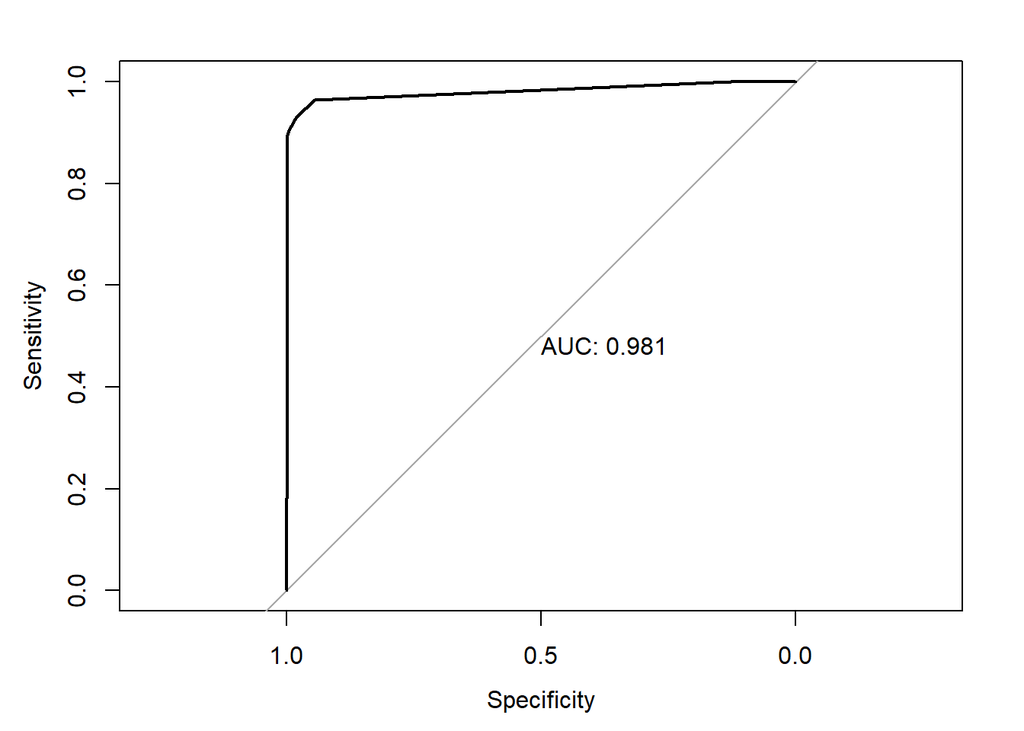

```r
plot(roc_obj, print.auc = T)
```

```r
roc_obj = roc(tstData$Personal_Loan, tstData$predict.score[,2])
```

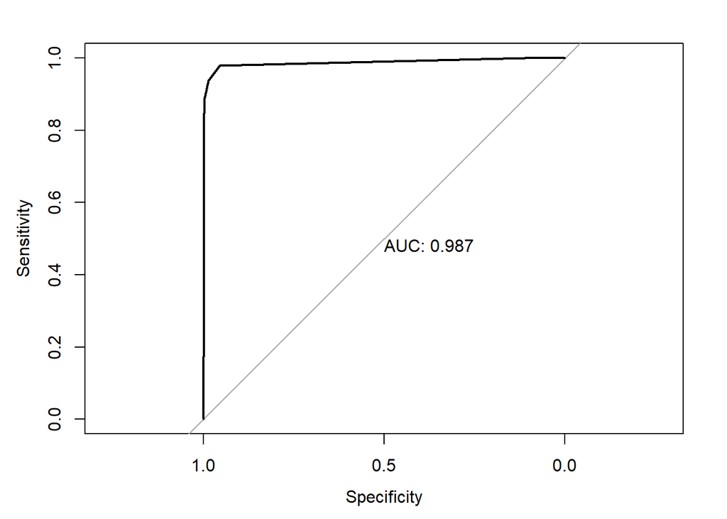

```r
plot(roc_obj, print.auc = T)
```

#####Random Forest####

#Step1: Trying to find best mtry by gridsearch

```r
#finding mtry

library(caret)
metric1="Accuracy"
tunegrid1 <- expand.grid(.mtry=c(1:12))
control=trainControl(search = "grid")
rf_gridsearch<-train(Personal_Loan~., data = trData, method ="rf",metric= metric1, tuneGrid =tunegrid1,trControl=control,ntree=500)
print(rf_gridsearch)
```

```
## Random Forest
##
## 3500 samples
##   13 predictor
##    2 classes: '0', '1'
##
## No pre-processing
## Resampling: Bootstrapped (25 reps)
## Summary of sample sizes: 3500, 3500, 3500, 3500, 3500, 3500, ...
## Resampling results across tuning parameters:
##
##   mtry  Accuracy   Kappa
##    1    0.9872037  0.9233917
##    2    0.9872652  0.9238831
##    3    0.9871399  0.9232126
##    4    0.9872666  0.9240730
##    5    0.9872369  0.9239682
##    6    0.9872053  0.9238164
##    7    0.9870781  0.9232148
##    8    0.9870779  0.9230967
##    9    0.9870465  0.9230413
##   10    0.9871086  0.9233116
##   11    0.9868287  0.9216951
##   12    0.9868578  0.9218360
##
## Accuracy was used to select the optimal model using the largest value.
## The final value used for the model was mtry = 4.
```

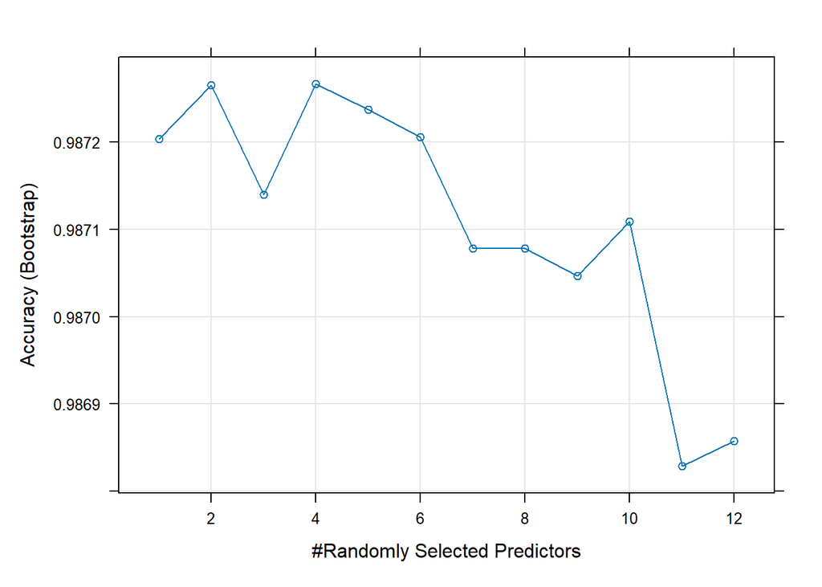

```r
plot(rf_gridsearch,metric="Accuracy")
```

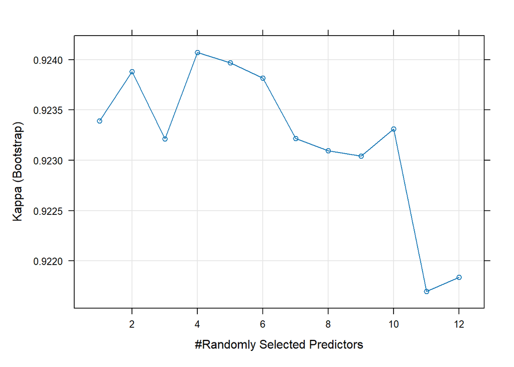

```r
plot(rf_gridsearch,metric="Kappa")
```

```r
library(randomForest)
set.seed(127)
trData$predict.class=NULL
trData$predict.score=NULL
tstData$predict.class=NULL
tstData$predict.score=NULL
attach(trData)
rf2<-randomForest(Personal_Loan~., data=trData,ntree=500,mtry=4,importance=TRUE)
rf2
```

```
##
## Call:
##  randomForest(formula = Personal_Loan ~ ., data = trData, ntree = 500,      mtry = 4, importance = TRUE)
##                Type of random forest: classification
##                      Number of trees: 500
## No. of variables tried at each split: 4
##
##         OOB estimate of  error rate: 1.23%
## Confusion matrix:
##      0   1 class.error
## 0 3157   7 0.002212389
## 1   36 300 0.107142857
```

#For Bringing down the false negative: changed cutoff to 70:30: Final RandomForest Model

```r
head(trData)
```

| Age_(in_years) | Experience_(in_years) | Income_(in_K/month) | Family_members | CCAvg | Education | Mortgage | Personal_Loan | Securities_Account | CD_Account | Online | CreditCard |
| --- | --- | --- | --- | --- | --- | --- | --- | --- | --- | --- | --- |
| 25 | 1 | 49 | 4 | 1.6 | 1 | 0 | 0 | 1 | 0 | 0 | 0 |
| 45 | 19 | 34 | 3 | 1.5 | 1 | 0 | 0 | 1 | 0 | 0 | 0 |
| 39 | 15 | 11 | 1 | 1.0 | 1 | 0 | 0 | 0 | 0 | 0 | 0 |
| 35 | 9 | 100 | 1 | 2.7 | 2 | 0 | 0 | 0 | 0 | 0 | 0 |
| 35 | 8 | 45 | 4 | 1.0 | 2 | 0 | 0 | 0 | 0 | 0 | 1 |
| 53 | 27 | 72 | 2 | 1.5 | 2 | 0 | 0 | 0 | 0 | 1 | 0 |

```r
set.seed(420)
library(randomForest)
rf3<-randomForest(Personal_Loan ~ ., data=trData,ntree=500,mtry=4,importance=TRUE,cutoff=c(0.7,0.3))
rf3
```

```
##
## Call:
##  randomForest(formula = Personal_Loan ~ ., data = trData, ntree = 500,      mtry = 4, importance = TRUE, cutoff = c(0.7, 0.3))
##                Type of random forest: classification
##                      Number of trees: 500
## No. of variables tried at each split: 4
##
##         OOB estimate of  error rate: 1.2%
## Confusion matrix:
##      0   1 class.error
## 0 3140  24 0.007585335
## 1   18 318 0.053571429
```

#Plot Random Forest Tree for 100th tree

```r
require(randomForest)
k <- 100
getTree(randomForest(Personal_Loan ~ ., data=trData,ntree=500,mtry=4,importance=TRUE,cutoff=c(0.7,0.3)), k, labelVar = TRUE)
```

|  | left daughter | right daughter | split var | split point | status | prediction |
| --- | --- | --- | --- | --- | --- | --- |
| 1 | 2 | 3 | Education | 1.00 | 1 | NA |
| 2 | 4 | 5 | CCAvg | 2.95 | 1 | NA |
| 3 | 6 | 7 | CD_Account | 1.00 | 1 | NA |
| 4 | 8 | 9 | Mortgage | 558.50 | 1 | NA |
| 5 | 10 | 11 | Family_members | 3.00 | 1 | NA |
| 6 | 12 | 13 | Income_(in_K/month) | 114.50 | 1 | NA |
| 7 | 14 | 15 | CCAvg | 2.25 | 1 | NA |
| 8 | 16 | 17 | Income_(in_K/month) | 132.50 | 1 | NA |
| 9 | 0 | 0 | NA | 0.00 | -1 | 1 |
| 10 | 18 | 19 | Income_(in_K/month) | 103.50 | 1 | NA |

[output cut: 123 more lines]

#Prediction for train data

```r
trData$predict.class=NULL
trData$predict.score=NULL

trData$predicted.class<-predict(rf3,trData,type="class")
trData$predicted.score<-predict(rf3,trData)

cfMatrix1<-table(trData$Personal_Loan,trData$predicted.class)
trueNegative<-cfMatrix1[1,1]
falsePositive<-cfMatrix1[1,2]
falseNegative<-cfMatrix1[2,1]
truePositive<-cfMatrix1[2,2]

cfMatrix1
```

```
##
##        0    1
##   0 3164    0
##   1    0  336
```

#Performance Measure for train Data

```r
sensetivityrf_tr=truePositive/(truePositive+falseNegative)
sprintf("Senstivity: %s", sensetivityrf_tr)
```

```
## [1] "Senstivity: 1"
```

```r
specificityrf_tr=trueNegative/(trueNegative+falsePositive)
sprintf("Specificity: %s", specificityrf_tr)
```

```
## [1] "Specificity: 1"
```

```r
accuracyrf_tr=(truePositive+trueNegative)/(truePositive+trueNegative+falsePositive+falseNegative)
sprintf("Accuracy: %s", accuracyrf_tr)
```

```
## [1] "Accuracy: 1"
```

#Prediction for test Data

```r
tstData$predicted.class<-NULL
tstData$predicted.score=NULL
head(tstData)
```

| Age_(in_years) | Experience_(in_years) | Income_(in_K/month) | Family_members | CCAvg | Education | Mortgage | Personal_Loan | Securities_Account | CD_Account | Online | CreditCard |
| --- | --- | --- | --- | --- | --- | --- | --- | --- | --- | --- | --- |
| 37 | 13 | 29 | 4 | 0.4 | 2 | 155 | 0 | 0 | 0 | 1 | 0 |
| 35 | 10 | 81 | 3 | 0.6 | 2 | 104 | 0 | 0 | 0 | 1 | 0 |
| 34 | 9 | 180 | 1 | 8.9 | 3 | 0 | 1 | 0 | 0 | 0 | 0 |
| 65 | 39 | 105 | 4 | 2.4 | 3 | 0 | 0 | 0 | 0 | 0 | 0 |
| 29 | 5 | 45 | 3 | 0.1 | 2 | 0 | 0 | 0 | 0 | 1 | 0 |
| 59 | 32 | 40 | 4 | 2.5 | 2 | 0 | 0 | 0 | 0 | 1 | 0 |

```r
tstData$predicted.class<-predict(rf3,tstData,type="class")
tstData$predicted.score<-predict(rf3,tstData)
cfMatrix1_tst<-table(tstData$Personal_Loan,tstData$predicted.class)
trueNegative1_tst<-cfMatrix1_tst[1,1]
falsePositive1_tst<-cfMatrix1_tst[1,2]
falseNegative1_tst<-cfMatrix1_tst[2,1]
truePositive1_tst<-cfMatrix1_tst[2,2]
cfMatrix1_tst
```

```
##
##        0    1
##   0 1343   13
##   1    8  136
```

#Performance Measure for test Data

```r
sensetivityrf_test=truePositive1_tst/(truePositive1_tst+falseNegative1_tst)
sprintf("Senstivity: %s", sensetivityrf_test)
```

```
## [1] "Senstivity: 0.944444444444444"
```

```r
specificityrf_test=trueNegative1_tst/(trueNegative1_tst+falsePositive1_tst)
sprintf("Specificity: %s", specificityrf_test)
```

```
## [1] "Specificity: 0.990412979351032"
```

```r
accuracyrf_test=(truePositive1_tst+trueNegative1_tst)/(truePositive1_tst+trueNegative1_tst+falsePositive1_tst+falseNegative1_tst)
sprintf("Accuracy: %s", accuracyrf_test)
```

```
## [1] "Accuracy: 0.986"
```

#Model Performance of Test and Train

```r
df_results_train = data.frame(accuracyrf_tr, sensetivityrf_tr, specificityrf_tr)
names(df_results_train) = c("ACC", "SENS", "SPEC")
df_results_test = data.frame(accuracyrf_test, sensetivityrf_test, specificityrf_test)
names(df_results_test) = c("ACC", "SENS", "SPEC")

?rbind
df_fin =rbind(df_results_train, df_results_test)
row.names(df_fin) = c('tree_full_train', 'tree_full_test')
df_fin
```

|  | ACC | SENS | SPEC |
| --- | --- | --- | --- |
| tree_full_train | 1.000 | 1.0000000 | 1.000000 |
| tree_full_test | 0.986 | 0.9444444 | 0.990413 |

#Calculating AUC with best model(rf3)

```r
trData$predicted.class=predict(rf3,trData,type="class")
trData$predicted.score=predict(rf3,trData,type="prob")
tstData$predicted.score=predict(rf3,tstData,type="prob")
```

```r
library(pROC)
roc_obj_rf1 = roc(trData$Personal_Loan, trData$predicted.score[,2])
```

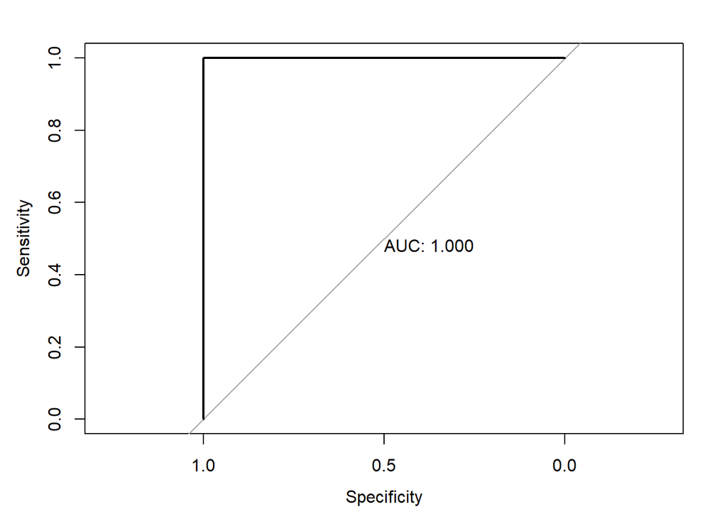

```r
plot(roc_obj_rf1, print.auc = T)
```

```r
roc_obj_rf2 = roc(tstData$Personal_Loan, tstData$predicted.score[,2])
```

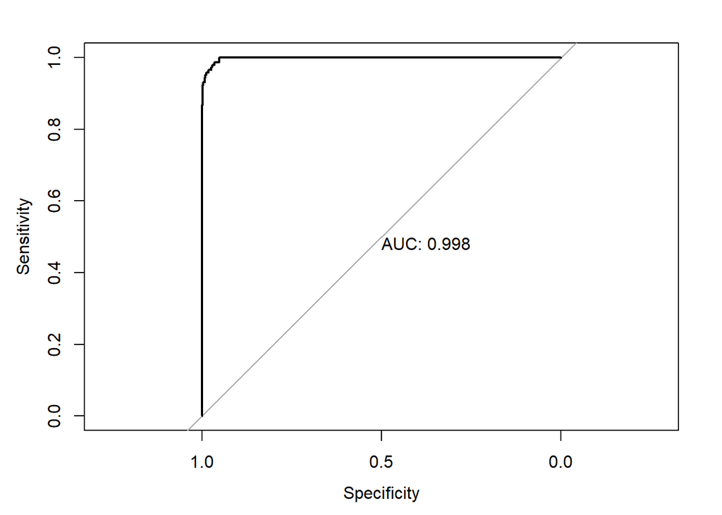

```r
plot(roc_obj_rf2, print.auc = T)
```